None

# Прогнозирование заказов такси

## Введение

Компания «Чётенькое такси» собрала исторические данные о заказах такси в аэропортах. Чтобы привлекать больше водителей в период пиковой нагрузки, нужно спрогнозировать количество заказов такси на следующий час. Постройте модель для такого предсказания.

Значение метрики *RMSE* на тестовой выборке должно быть не больше 48.

Вам нужно:

1. Загрузить данные и выполнить их ресемплирование по одному часу.
2. Проанализировать данные.
3. Обучить разные модели с различными гиперпараметрами. Сделать тестовую выборку размером 10% от исходных данных.
4. Проверить данные на тестовой выборке и сделать выводы.

Данные лежат в файле `taxi.csv`. Количество заказов находится в столбце `num_orders` (от англ. *number of orders*, «число заказов»).

## Библиотеки и настройки

Библиотеки

```python
import pandas as pd

from statsmodels.tsa.seasonal import seasonal_decompose

import numpy as np


# для графиков
import matplotlib.pyplot as plt
import seaborn as sns

# для скрытия ошибок
import warnings
from IPython.display import display
#для загрузки данных и с сервера и локально
import os

# регулярные выражения
import re

# метод Дики-Фуллера
from statsmodels.tsa.stattools import adfuller

# для разбиение на выборки
from sklearn.model_selection import train_test_split
# метрика MSE
from sklearn.metrics import mean_squared_error
# GridSeachCV для подбора параметров на кроссвалидации
from sklearn.model_selection import GridSearchCV
# разбиение на тренировочную и проверочную выборку для временных рядов
from sklearn.model_selection import TimeSeriesSplit
# для проверки адекватности моделей
from sklearn.dummy import DummyRegressor
# Линейная регрессия
from sklearn.linear_model import LinearRegression
# Ridge регрессия
from sklearn.linear_model import Ridge
# ElasticNet регрессия
from sklearn.linear_model import ElasticNet
# Lasso регрессия
from sklearn.linear_model import Lasso
# для создания конвеера/ трудопровода
from sklearn.pipeline import Pipeline, make_pipeline
# для маштабирования признаков
from sklearn.preprocessing import StandardScaler
# заполнение пропусков
from sklearn.impute import SimpleImputer
```

Настройки

```python
# для скрытия ошибок
warnings.filterwarnings("ignore")

# для увеличения окна вывода
pd.options.display.max_rows = 300
# максимальная вместимость ячейки для отображения
pd.set_option('display.max_colwidth', None)
# четыре знака после запятой
pd.set_option('display.float_format', '{:.4f}'.format)

# для задания размера графиков по умолчанию
plt.rcParams["figure.figsize"] = (7, 5)

# для псевдорандомных значений
np.random.seed(seed=321)
np.random.RandomState(seed=321)
```

```
RandomState(MT19937) at 0x7F100DCDD840
```

## Подготовка

### Загрузка данных

Во время загрузки данных мы сразу переведём даты из формата строк в формат даты и сами даты сделаем индексами для удобства работы.

```python
#путь с сервероной версии
pth1 = '/datasets/taxi.csv'
# моя локальная версия
pth2 = 'taxi.csv'

# загрузка данных
if os.path.exists(pth1):
    df = pd.read_csv(pth1, index_col=[0], parse_dates=[0])
elif os.path.exists(pth2):
    df = pd.read_csv(pth2, index_col=[0], parse_dates=[0])
else:
    display('Проверьте пути к файлам с данными!')

df.info()
df.head()
```

```
<class 'pandas.core.frame.DataFrame'>
DatetimeIndex: 26496 entries, 2018-03-01 00:00:00 to 2018-08-31 23:50:00
Data columns (total 1 columns):
 #   Column      Non-Null Count  Dtype
---  ------      --------------  -----
 0   num_orders  26496 non-null  int64
dtypes: int64(1)
memory usage: 414.0 KB
```

| datetime | num_orders |
| --- | --- |
| 2018-03-01 00:00:00 | 9 |
| 2018-03-01 00:10:00 | 14 |
| 2018-03-01 00:20:00 | 28 |
| 2018-03-01 00:30:00 | 20 |
| 2018-03-01 00:40:00 | 32 |

**Выводы**:

- Данные загружены корректно.
- У нас есть данные с марта по август 2018 года включительно.
- Данные с переодисностью в 10 минут.

Для решения нашей задачи нам нужно будет изменить данные: сделать период в 1 час.

### Ресемплинг

Проверим являются ли наши индексы/даты отсортированными по возростанию.

```python
df.index.is_monotonic_increasing
```

```
True
```

Сделаем ресемплинг: сделаем период в 1 час и запишем суммы вызванных такси внутри этого часа.

```python
df = df.resample('1H').sum()
df.info()
df.head()
```

```
<class 'pandas.core.frame.DataFrame'>
DatetimeIndex: 4416 entries, 2018-03-01 00:00:00 to 2018-08-31 23:00:00
Freq: H
Data columns (total 1 columns):
 #   Column      Non-Null Count  Dtype
---  ------      --------------  -----
 0   num_orders  4416 non-null   int64
dtypes: int64(1)
memory usage: 69.0 KB
```

| datetime | num_orders |
| --- | --- |
| 2018-03-01 00:00:00 | 124 |
| 2018-03-01 01:00:00 | 85 |
| 2018-03-01 02:00:00 | 71 |
| 2018-03-01 03:00:00 | 66 |
| 2018-03-01 04:00:00 | 43 |

**Вывод**: Теперь наши данные готовы к анализу и работы над нашим заданием.

## Анализ

### Первая визуализация

У нас более 4000 объектов. Лучше всего посмотреть на них на графике.

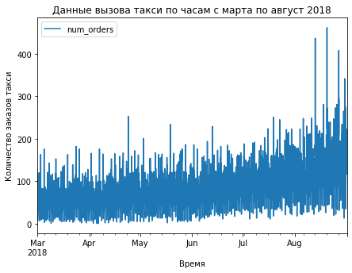

```python
df.plot(title = 'Данные вызова такси по часам с марта по август 2018'
       , ylabel = 'Количество заказов такси'
        , xlabel = 'Время'
        )

plt.show()
```

Посмотрим июнь 2018 года.

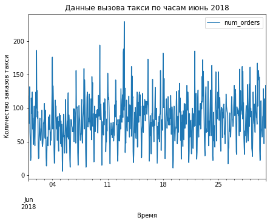

```python
df['2018-06-01':'2018-06-30'].plot(title = 'Данные вызова такси по часам июнь 2018'
       , ylabel = 'Количество заказов такси'
        , xlabel = 'Время'
        )

plt.show()
```

Первые 7 дней июня.

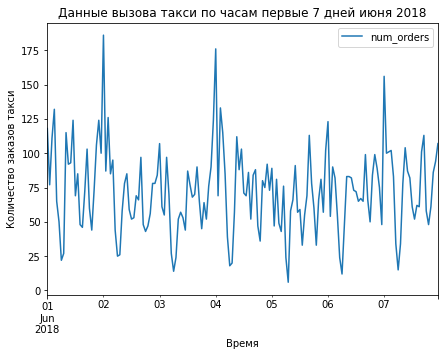

```python
df['2018-06-01':'2018-06-07'].plot(title = 'Данные вызова такси по часам первые 7 дней июня 2018'
       , ylabel = 'Количество заказов такси'
        , xlabel = 'Время'
        )

plt.show()
```

Одни день - 01 июня 2018 года.

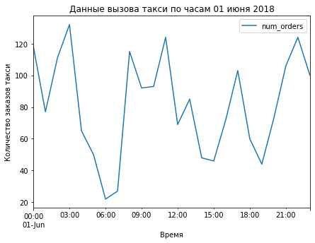

```python
df['2018-06-01'].plot(title = 'Данные вызова такси по часам 01 июня 2018'
       , ylabel = 'Количество заказов такси'
        , xlabel = 'Время'
        )

plt.show()
```

**Выводы**:

- Так как это данные для вызовов такси в аэропорт, то мы видим схожие значения от недели к неделе.
- А так же резкие перепады от часа к часу, что, вероятно, вызвано расписанием самолетов.
- Количество вызовов такси имеет схожие, медленно растущие значения по месяцам.
- Имеются данные которые резко выделяются на общем фоне (в 2 раза выше среднего), их больше в августе.

Используем декомпозицию, чтобы понять тренды и сезонность.

### Тренды, сезонность и шумы

Выделим в наших данных 3 составляющие: тренды, сезонность и шумы.

```python
decomposed = seasonal_decompose(df)
```

```python
# decomposed.plot()
# plt.figsize=(7, 20)
# plt.show()
```

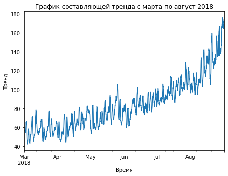

```python
decomposed.trend.plot(title='График составляющей тренда с марта по август 2018'
                      , xlabel='Время'
                      , ylabel='Тренд'
                     )
plt.show()
```

Как видим у нас есть растущий тренд.

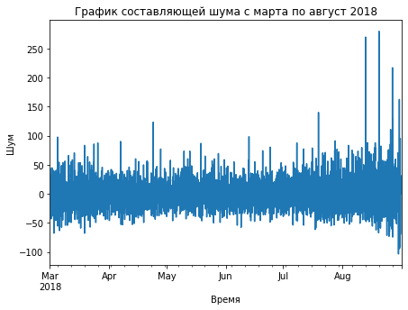

```python
decomposed.resid.plot(title='График составляющей шума с марта по август 2018'
                      , xlabel='Время'
                      , ylabel='Шум'
                     )
plt.show()
```

Как видим шумы сильно возрастают в августе.

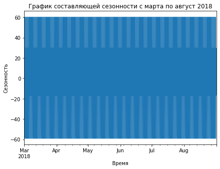

```python
decomposed.seasonal.plot(title='График составляющей сезонности с марта по август 2018'
                      , xlabel='Время'
                      , ylabel='Сезонность'
                     )
plt.show()
```

Сезонность у нас "рябит" посмотрим не нее под увеличительным стеклом.

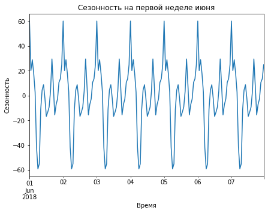

```python
decomposed.seasonal['2018-06-01':'2018-06-07'].plot(title = 'Сезонность на первой неделе июня'
                                                   , xlabel = 'Время'
                                                    , ylabel='Сезонность'
                                                   )
plt.show()
```

Увеличивали, увеличивали и на недельном отрезке увидили, что сезонность у нас дневная (24 часа). **А есть ли другая?** Посмотрим в дополнительном разделе.

#### Дополнительно

Посмотрим на сезонность при сэмплировании по дням.

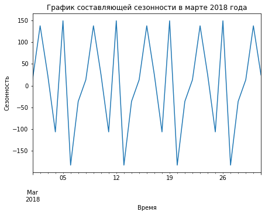

```python
decomposed = seasonal_decompose(df.resample('1D').sum())
# decomposed.plot()
# plt.show()
decomposed.seasonal['2018-03'].plot(title='График составляющей сезонности в марте 2018 года'
                      , xlabel='Время'
                      , ylabel='Сезонность'
                     )
plt.show()
```

**Вывод**: Оказывается у нас есть ещё и недельная сезонность. Что очень логично для работы такси в аэропорту.

#### Вывод и заметки на будующее

Исходя из проанализированной нами сезонности, которая составила 1 день или 24 часа и 7 дней или 168 часов, составим следующие параметры для поиска лучших параметров для подготовки дополнительных признаков:

```python
# param_max_lag = [0, 6, 12, 24, 48]
# param_rolling_mean_size = [1, 6, 12, 24]
param_max_lag = [0, 24, 168]
param_rolling_mean_size = [12, 24, 168]
```

где `max_lag` это число колонок, каждая из которых является сдвигом на 1 шаг друг от друга, а исходная это колонка нашего целевого признака,

`rolling_mean_size` это размер окна для расчета плавающей средней.

### Стационарность ряда

#### Скользящее среднее и стандартное отклонение

Расчитаем и отобразим скользящие средние и стандартное отклонение

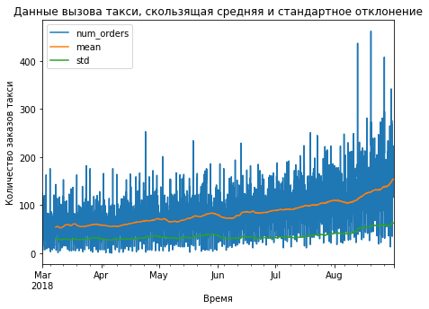

```python
df['mean'] = df['num_orders'].rolling(window=24*7, closed='left').mean()
df['std'] = df['num_orders'].rolling(window=24*7, closed='left').std()

df.plot(title = 'Данные вызова такси, скользящая средняя и стандартное отклонение'
       , ylabel = 'Количество заказов такси'
        , xlabel = 'Время'
       )

plt.show()
```

Чтобы лишняя информация не давала моделям подглядывать в будующем, уберём наши расчеты из основных данных.

```python
df.drop(columns=['mean', 'std'], inplace=True)
df.info()
```

```
<class 'pandas.core.frame.DataFrame'>
DatetimeIndex: 4416 entries, 2018-03-01 00:00:00 to 2018-08-31 23:00:00
Freq: H
Data columns (total 1 columns):
 #   Column      Non-Null Count  Dtype
---  ------      --------------  -----
 0   num_orders  4416 non-null   int64
dtypes: int64(1)
memory usage: 198.0 KB
```

Возможно, для некоторых моделей и существующей стационарности будет достаточно.

А для других нужен будет более стационарный ряд, который возможно получить за счет *разности временного ряда*.

#### Тест Дики - Фуллера

Проверим гипотезу: Наш временный рад заказов такси на стационарен;

```
H_0: Наш временный ряд заказов такси не стационарный
H_1: Наш временныя ряд заказов такси стационарный
alpha_1 = 1%
alpha_2 = 5%
```

Так как ряды можно сравнивать по уровню стационарности, то мы возьмем 2 порога: 1% и 5% для понимания уровня стационарности ряда. Тоесть, если будет перейдень 5% порог, то ряд настолько не стационарный, что нам нужны специальные методы подготовки данных для работы моделей, если не перейдет 1% порог, то ряд стационарный и нам специальные методы не нужны, значения между 1% и 5% порогами означает, что модели могут дать хорошие результаты и без специальных методов и с ними.

```python
alpha_1 = '1%'
alpha_2 = '5%'

result = adfuller(df['num_orders'], autolag='AIC')

display('Критерий ADF: %f' % result[0])

display('P-значение: %f' % result[1])

display('Критические значения:')

for key, value in result[4].items():
    display('%s: %.3f' % (key, value))

display('Для 1% порога:')
if result[0] < result[4][alpha_1]:
    print ("Нулевая гипотеза отвергнута – Временной ряд стационарен")
else:
    print ("Нулевая гипотеза не отвергнута – Временной ряд не стационарен")

display('Для 5% порога:')
if result[0] < result[4][alpha_2]:
    print ("Нулевая гипотеза отвергнута – Временной ряд стационарен")
else:
    print ("Нулевая гипотеза не отвергнута – Временной ряд не стационарен")
```

```
'Критерий ADF: -3.068924'
```

```
'P-значение: 0.028940'
```

```
'Критические значения:'
```

```
'1%: -3.432'
```

```
'5%: -2.862'
```

```
'10%: -2.567'
```

```
'Для 1% порога:'
```

```
Нулевая гипотеза не отвергнута – Временной ряд не стационарен
```

```
'Для 5% порога:'
```

```
Нулевая гипотеза отвергнута – Временной ряд стационарен
```

**Вывод**: Наш ряд не стационарен. По тесту Дики-Фуллера оценка его стационароности находится между 1% и 5% порогами. Это значит, что модели могут показать хорошие результаты как на самом ряду так и на специально подготовленными данными (разница временных радов для стационарности ряда).

#### Выводы о стационарности ряда.

Наши выводы на основе скользящей средней, стандартного отклонения и теста Дики-Фуллера сошлись. Наш временной ряд не строго стационарный, поэтому подготовим данные, чтобы стационароность была создана за счет разницы временных рядов.

## Обучение

Так как нам нужно предсказать количество заказов такси на следующий час, то **наша задача, является задачей регрессии и прогнозирования. Горизонт планирования - 1 час**

### Метрика

По условияю задания нашей метрикой будет *RMSE*. Это как *MSE* только под квадратным корнем.

### Генератор псевдослучайных значений

В этом проекте для вычеслений и выборок будет использоваться механизм генератора псевдослучайных значений. Для нашего проекта мы выбрали этот параметр `random_state` равным **321** для всего проекта.

```python
rs=321
```

### Подготовка к проверке адекватности модели

Так как в нашем задании указан строкий критерий: **RMSE <= 48**, то мы будем опираться на этот критерий, и ~не будет строить~ на результаты моделей для отображения порога адекватности.

```python
# модель которая предсказывает значение средней в тренировочной выборке во всех предсказаниях
dummy_model = DummyRegressor(strategy='mean')
```

### Создание признаков

Так как мы работаем с временным радом и дата у нас спрятана в индексы, а обучающий признак является в то же время и целевым( спасает только шаг прогнозирования), то нам нужно создать обучающие признаки для моделей: вытащить всё что можно из индесов и данных.

Напишем для этого функцию, которая будет получать на вход:

- данные(`data`)
- размер лага(`max_lag`): это поможет стабилизировать временной ряд за счет разницы временных рядов
- размер окна для расчета плавающей средней(`rolling_mean_size`)

И возвращать данны с созданными дополнительными признаками.

```python
def make_features(data, max_lag, rolling_mean_size):
    data_copy = data.copy()
#     data_copy['year'] = data_copy.index.year # это на перспективу роста входных данных
#     data_copy['month'] = data_copy.index.month
    data_copy['day'] = data_copy.index.day
    data_copy['dayofweek'] = data_copy.index.dayofweek
    data_copy['hour'] = data_copy.index.hour

    for lag in range(1, max_lag + 1):
        data_copy['lag_{}'.format(lag)] = data_copy['num_orders'].shift(lag)

    data_copy['rolling_mean'] = data_copy['num_orders'].shift().rolling(rolling_mean_size).mean()
    return data_copy
```

### Разбиение данных на выборки

По условиям у нас будет 2 выборки: тренировочная - 90%, тестовая - 10%. Так как мы работаем с временным рядом, то для нас важно, чтобы данные не были перемешаны.

```python
test_size = 0.1
```

Так как у нас не много данных и размер проверочной/валидационной выборки не указан, то мы будем пользоваться **GridSeachCV**, так как он может решить обе наши проблемы.

```python
ts_cv = TimeSeriesSplit(
    n_splits=3,
    gap=24,
)
```

### Целевой и обучающий признаки

Нашим целевым признаком является - `num_orders`.

А обучающими признаки полученные сдвигом `num_orders`, признаки и даты и времени и их производные(скользящие средние). Для этого нам пригодится наша функция `make_features`.

Напишем функцию, которая будет получать на входе данные, а на выходе выдавать обучающие признаки и целевой признак.

```python
target_name = 'num_orders'
```

```python
def features_target_separator(data, target_name):
    target = data[target_name]
    features = data.drop(columns=target_name)
    return features, target
```

### Поиск лучшей модели

И так... Мы можем управлять набором признаков!

Для поиска лучшей модели мы будем использовать **GridSearchCV**.

Таким образом мы для разных вариантов набора признаков будем искать лучшие модели, а лучшая модель с лучшими параметрами для создания признаков будут работать на тествой выборке!

#### Модели и их параметры для выбора лучшей в GridSearchCV

Чтобы заработали наши сдвиги, которые повышают статичность временного ряда мы будем использовать, в основном, линейные модели.

```python
# параметры для улучшения моделей в GridSearchCV для линейных алгоритмов - регуляризация

params_linear = [{'regressor': [LinearRegression()]
                }
          , {'regressor': [Ridge()]
            , 'regressor__alpha': [0.2, 0.4, 0.6, 0.8, 1] # default 1.0
             , 'regressor__solver': ['auto', 'svd', 'cholesky', 'lsqr', 'sparse_cg', 'sag', 'saga']
             , 'regressor__random_state': [None, rs]
          }
          , {'regressor': [Lasso()]
            , 'regressor__alpha': [0.2, 0.4, 0.6, 0.8, 1] # default 1.0
             , 'regressor__random_state': [None, rs]
          }
          , {'regressor': [ElasticNet()]
             , 'regressor__alpha': [0.2, 0.4, 0.6, 0.8, 1] # default 1.0
            , 'regressor__l1_ratio': [0, 0.25, 0.5, 0.75, 1] # default 0.5
             , 'regressor__random_state': [None, rs]
          }
        ]
```

#### Преподготовка данных

Подготовим предобработку обучающих признаков прежде чем они будут попадать моделям.

```python
# обработка численных признаков специально для линейных моделей: заполнение пропусков нулями + метки
# о заполнении пропуска в отдельном столбце,
# стандартизация и маштабирование
preprocessor_steps_linear = [('imputer', SimpleImputer(missing_values=np.nan
                                                       , strategy='constant'
                                                       , fill_value=0
                                                       , add_indicator=True
                                                      )
                             )
             , ('scaler', StandardScaler())]
preprocessor_linear = Pipeline(preprocessor_steps_linear)
```

#### Шаги по умолчанию для pipeline для GridSearchCV

```python
# шаги для pipeline в GridSearchCV для линейных моделей
steps_linear = [('preprocessor', preprocessor_linear), ('regressor', LinearRegression(n_jobs=-1))]
```

#### Функция для выбора лучшего pipeline/модели

Напишем функцию, которая будет производить поиск лучшего pipeline/модели для выбраного целевого признака.

```python
# на вход идут признаки, целевой признак, шаги по умолчанию для pipeline, метод расчета (smape_scorer),
# параметр для отображения процесса работы
# на выход лучший обученный объект GridSearchCV
#
def pipeline_gridsearchcv(X, y, steps, params
#                           , scoring
                          , verbose = 1):

    # формируем итоговый pipeline
    pipe = Pipeline(steps)

    # собираем все вместе, запускаем поиск
    grid = GridSearchCV(pipe, param_grid=params
                        , cv= ts_cv # можно поэксперементировать от 3 до 5, важно, чтобы shuffle=False
                        , n_jobs=-1
                        , scoring='neg_root_mean_squared_error' #RMSE
                        , verbose=verbose
                        , error_score='raise')
    grid.fit(X, y)

#     #Посмотрим наилучшие подобранные параметры
#     display('')
#     display('Параметры лучшей модели:', grid.best_params_)
#     display('Значение лучшей метрики качества:', -grid.best_score_)

    return grid
```

#### Главный поиск

```python
# по условиям задачи нужно, чтобы RMSE было меньше 48
best_rmse = 48

for lag in param_max_lag:
    for rol in param_rolling_mean_size:
        # добавляем признаки
        data = make_features(df, lag, rol)
        # разбиваем на тренировочную и тестовую выборки
        train, test = train_test_split(data, shuffle=False, test_size=test_size, random_state=rs)
        # выделяем обучающие и целевой признаки для тренировочной выборки
        features_train, target_train = features_target_separator(train, target_name)
#         # выделяем обучающие и целевой признаки для тестовой выборки
#         features_test, target_test = features_target_separator(test, target_name)
        # подбираем лучшую модель для данных этого шага цикла на тренировочной выборке
        grid_search_linear = pipeline_gridsearchcv(features_train, target_train, steps_linear, params_linear)
        # запись лучших параметров
        if best_rmse > -grid_search_linear.best_score_:
            best_grid = grid_search_linear
            best_lag = lag
            best_rolling_mean_size = rol


#Посмотрим наилучшие подобранные параметры
display('')
# display('Параметры лучшей модели:', best_grid.best_params_)
display('Значение лучшей метрики качества:', -best_grid.best_score_)
```

```
Fitting 3 folds for each of 131 candidates, totalling 393 fits
Fitting 3 folds for each of 131 candidates, totalling 393 fits
Fitting 3 folds for each of 131 candidates, totalling 393 fits
Fitting 3 folds for each of 131 candidates, totalling 393 fits
Fitting 3 folds for each of 131 candidates, totalling 393 fits
Fitting 3 folds for each of 131 candidates, totalling 393 fits
Fitting 3 folds for each of 131 candidates, totalling 393 fits
Fitting 3 folds for each of 131 candidates, totalling 393 fits
Fitting 3 folds for each of 131 candidates, totalling 393 fits
```

```
''
```

```
'Значение лучшей метрики качества:'
```

```
22.399894025402787
```

```python
best_model = best_grid.best_estimator_
```

А что же с параметрами для подготовки данных?

```python
best_lag
```

```
168
```

```python
best_rolling_mean_size
```

```
168
```

#### Вывод

Лучшая модель и лучшие параметры для подготовки признаков найдены. Нужно провести тестирование.

**Заметка**: параметр `best_lag` не равен 0. Значит для компенсации недостаточной стационарности моделям понадобились разницы временного ряда.

## Тестирование

### Тестирование модели

Тестирование не будет простым, так как нам нужно:

- создать дополнительные признаки
- разбить данные на 2 выборки: тренировочную и тестовую
- в каждой из выборок выделить целевой признак и обучающие
- обучить модель на тренировочной выборке
- и наконец... сделать предсказание и посчитать RMSE на тестовой выборке.

```python
# добавляем признаки
data = make_features(df, best_lag, best_rolling_mean_size)
# разбиваем на тренировочную и тестовую выборки
train, test = train_test_split(data, shuffle=False, test_size=test_size, random_state=rs)
# выделяем обучающие и целевой признаки для тренировочной выборки
features_train, target_train = features_target_separator(train, target_name)
# обучаем лучшую модель
best_model.fit(features_train, target_train)
# выделяем обучающие и целевой признаки для тестовой выборки
features_test, target_test = features_target_separator(test, target_name)
# считаем RMSE на тестовой выборке
prediction_best_model = best_model.predict(features_test)
mean_squared_error(target_test, prediction_best_model, squared=False)
```

```
34.914808228856245
```

**Вывод**: RMSE на тестовой выборке меньше 48. Основной критерий заказчика выполнен. Но нужно еще проверить на адекватность.

### Проверка адекватности модели

Результат получен, но адекватен ли он? У нас подготовлена модель, которая будет предсказывать средннее обучающей выборки, и есть все подготовленные данные. **Время проверки на адекватность модели**.

```python
dummy_model.fit(features_train, target_train)
prediction_dummy_model = dummy_model.predict(features_test)
mean_squared_error(target_test, prediction_dummy_model, squared=False)
```

```
84.74414402014742
```

**Вывод**: Любая модель с результатом меньше 84,74 RMSE может считаться адекватной.

### Визуализация результатов работы моделей

Посмотрим графически на работу нашей лучшей модели, модели для проверки адекватности и настоящих значений.

[figure not shown]

```python
ax = target_test.plot(label='target_test', alpha=0.7, legend=True)
pd.Series(prediction_best_model, index=target_test.index).plot(ax=ax, legend=True, grid=True
                                                               , label='prediction_best_model', alpha=0.7)
pd.Series(prediction_dummy_model, index=target_test.index).plot(ax=ax, legend=True, grid=True
                                                               , label='prediction_dummy_model', alpha=0.7)


plt.title('График сравнения значений и предсказаний')
plt.ylabel('Количество заказов такси')
plt.xlabel('Время')
plt.show()
```

Ух ты нам для предсказаний достался самый сложных отрезок времени с самым большим количеством шумов и самым выраженным ростом заказов такси.

**Вывод**: Наша лучшая модель действительно хороша: уложилась в критерии заказчика на самом трудном отрезке времени.

### Вывод:

Тестирование прошло успешно. Результат модели адекватен и выполняет критерии заказчика.

## Общий вывод

С поставленной задачей в этом проекте мы справились. Найдена не только модель, но параметры для подготовки обучающих признаков.

Для выполнения этой задачи:

Конечно, для всего были написаны необходимые функции.